# Capstone Project - The Battle of the Neighborhoods (Week 2)

### Introduction/Business Problem

In this project I will compare Ankara and Istanbul which are two of the three largest cities in Turkey. Ankara is the capital city of Turkeya and Istanbul is one of the largest metropolises in the world.

While more than 15 million people live in Istanbul, Ankara has a population of about 5 million. Ankara is the political center and Istanbul is the trade center of the country. Also, historical texture and cultural activities make Istanbul a center of attraction.

I will examine and compare the neighborhoods of two cities for representing the skills that I have gained during the IBM Data Science Professional Certificate program.

### Data

Second-level Administrative Divisions of the Turkey from Spatial Data Repository of NYU (https://geo.nyu.edu/catalog/stanford-nj696zj1674) will be used for obtaining the boroughs of two cities. This source provide us data related to districts of all cities in Turkey. I will filter the data for creating datasets of boroughs of Ankara and Istanbul.

Forsquare API will be used to get the most common venues of given Borough of Ankara and Istanbul.

##### Exploratory Data Analysis

Datasets of boroughs of Ankara and Istanbul have been created by using the data obtained from Second-level Administrative Divisions of the Turkey from Spatial Data Repository of NYU. There are 38 boroughs for Istanbul and 24 boroughs for Ankara.

The most common avenues of given boroughs of Ankara and Istanbul have been obtained by using Foursquare API. Since the coordinates of neighborhoods in boroughs could not be reached, coordinates of boroughs have been used for getting the venues. Radius value has been specified as 1000m. Bar plots of venues in the booroughs have been shown below graphs.

##### Bar Plot Of Ankara Venues

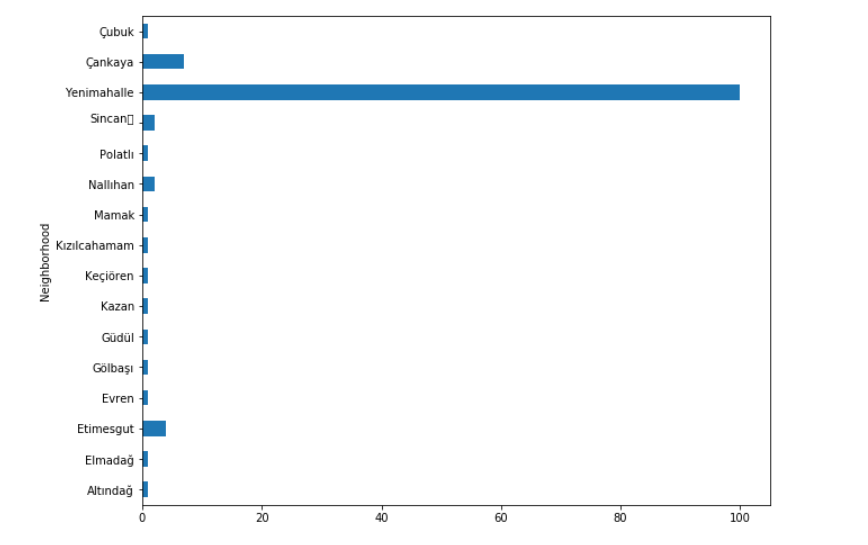

##### Bar Plot Of İstanbul Venues

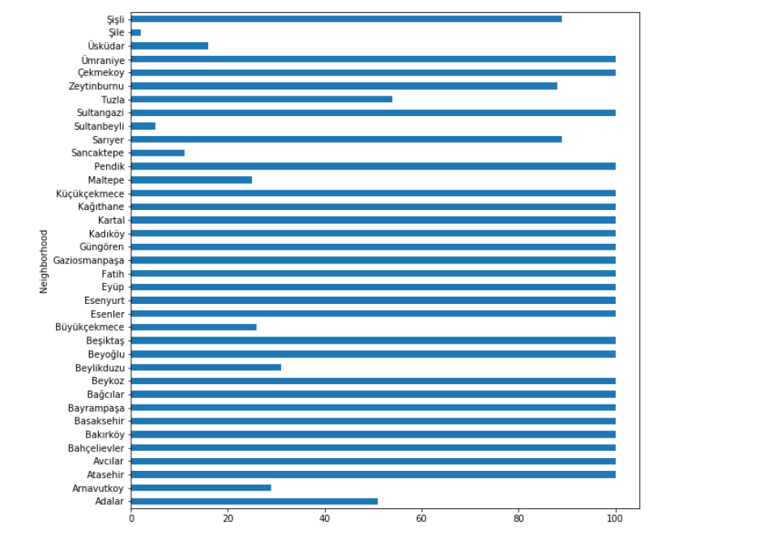

I have obtained 126 venues for Ankara and 2916 venues for Istanbul. Information of venues could not be reached for 8 of 24 boroughs of Ankara and 1 of 38 boroughs of Istanbul. Then, the most common venues have been examined for two cities and tables have been created for the 5 most common venues in the boroughs.

##### Table of 5 Most Common Venues in Boroughs of Ankara

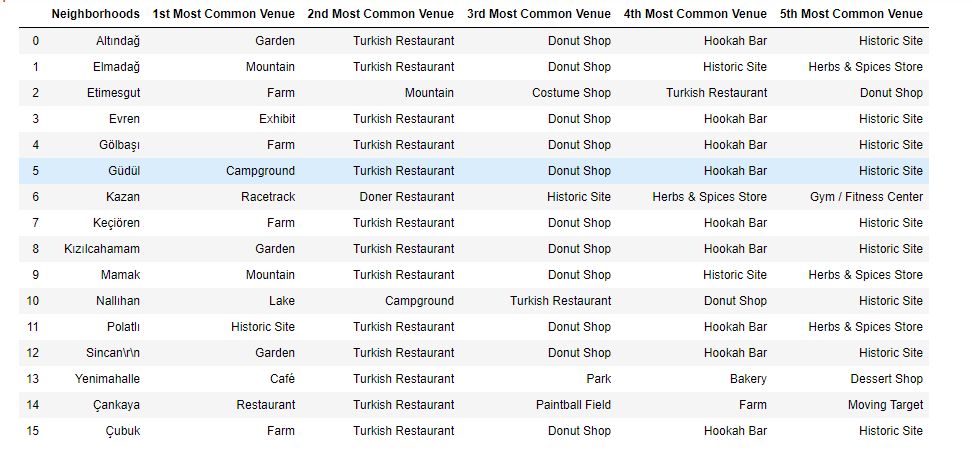

##### Table of 5 Most Common Venues in Boroughs of İstanbul

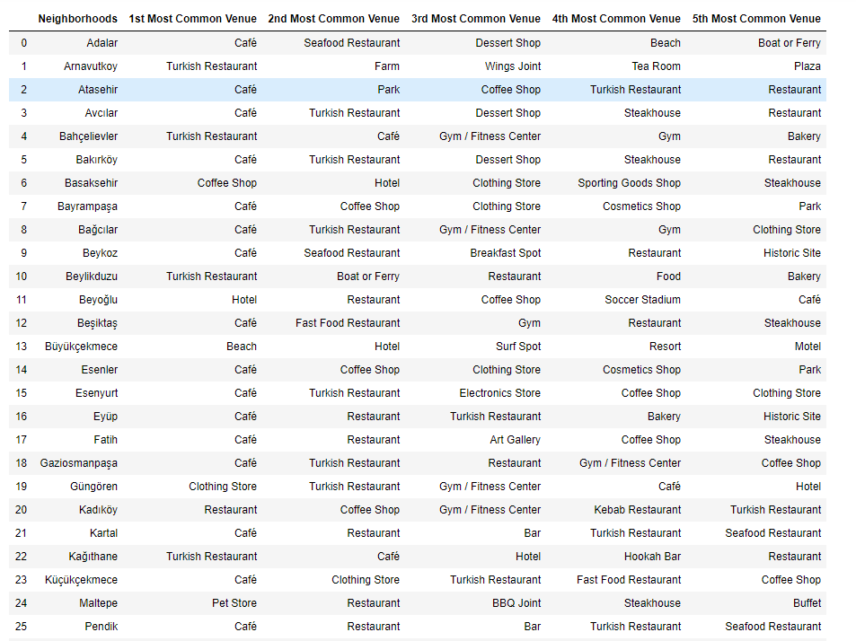

### Clustering

Firstly, I have applied elbow method for specifying the number of clusters for K-means clustering. According to the plots I have specified the number of clusters for Ankara as 8 and for Istanbul as 6.

##### Elbow Method for Ankara

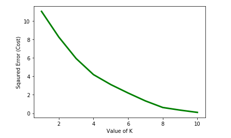

##### Elbow Method for Istanbul

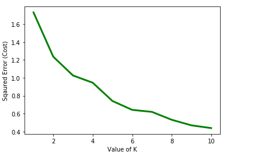

Then k-means clustering is applied with the given number of clusters. Then the tables were merged with the cluster numbers. Lastly, the clusters have been examined on the maps.

### Results

##### Maps of Cluester of Venues in Boroughs of Ankara

[figure not shown]

##### Maps of Cluester of Venues in Boroughs of Istanbul

[figure not shown]

### Discussion

Firstly, since the coordinates of the neighborhoods in the boroughs could not be reached venues could not be reached effectively. Although Çankaya is known to be the center of the city there are not as much places as in Yenimahalle. If the neighborhood coordinates are obtained the venues in Çankaya can be obtained more effectively. This can effect the results of clustering.

### Conclusion

There are big differences in terms of the distribution of the venues between two cities as expected. These analysis should be expanded with the neighborhood coordinates. Investors and people who think about working in these cities can benefit from these kind of analysis.